# Stats 330 Assignment 4

Xinning Gong 865308655

23/05/2021

## Question 1 Mice

The data for this question comes from a study that investigated the effect of insulin on laboratory mice. The response was whether or not the mice had convulsions when given insulin. We are interested in modelling how the proportion of mice with convulsions differs for a new preparation method compared to the standard method.

### a) Data frame

```r
method <- c("Standard Method", "Standard Method", "Standard Method", "Standard Method", "Standard Method", "Standard Method", "Standard Method", "Standard Method", "Standard Method", "New Method", "New Method", "New Method", "New Method", "New Method")
dose <- c(3.4, 5.2, 7.0, 8.5, 10.5, 13.0, 18.0, 21.0, 28.0, 6.5, 10.0, 14.0, 21.5, 29.0)

convulsion <- c(0, 5, 11, 14, 18, 21, 23, 30, 27, 2, 10, 18, 21, 27)

total <- c(33, 32, 38, 37, 40, 37, 31, 37, 30, 40, 30, 40, 35, 37)

mice.df <- data.frame(method, dose, convulsion, total)
mice.df$method <- as.factor(mice.df$method)
mice.df
```

```
##             method dose convulsion total
## 1  Standard Method  3.4          0    33
## 2  Standard Method  5.2          5    32
## 3  Standard Method  7.0         11    38
## 4  Standard Method  8.5         14    37
## 5  Standard Method 10.5         18    40
## 6  Standard Method 13.0         21    37
## 7  Standard Method 18.0         23    31
## 8  Standard Method 21.0         30    37
## 9  Standard Method 28.0         27    30
## 10      New Method  6.5          2    40
## 11      New Method 10.0         10    30
## 12      New Method 14.0         18    40
## 13      New Method 21.5         21    35
## 14      New Method 29.0         27    37
```

### b) Model fit

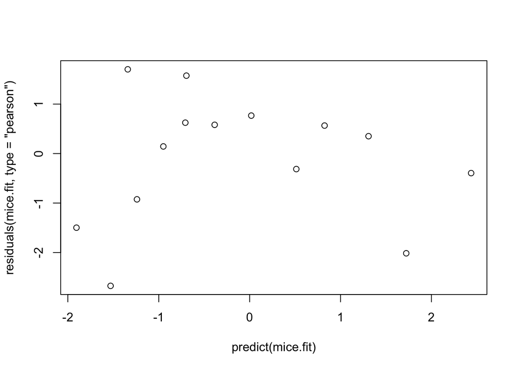

```r
mice.fit <- glm(cbind(convulsion, total - convulsion) ~ dose + method, family = "binomial")
plot(predict(mice.fit), residuals(mice.fit, type = "pearson"))
```

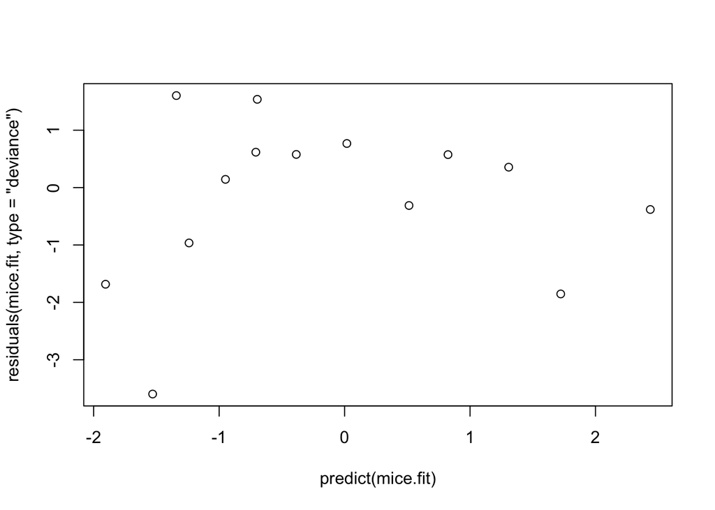

```r
plot(predict(mice.fit), residuals(mice.fit, type = "deviance"))
```

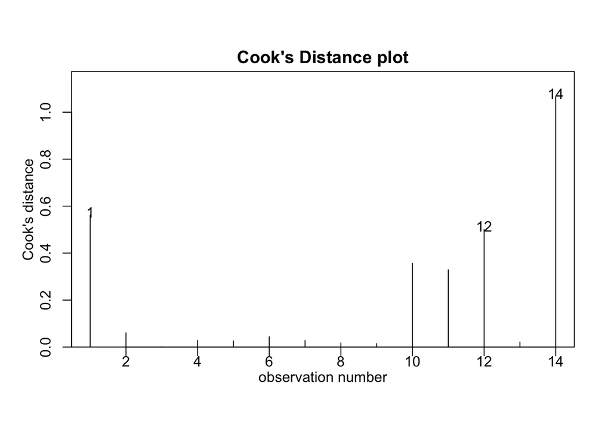

```r
cooks20x(mice.fit)
```

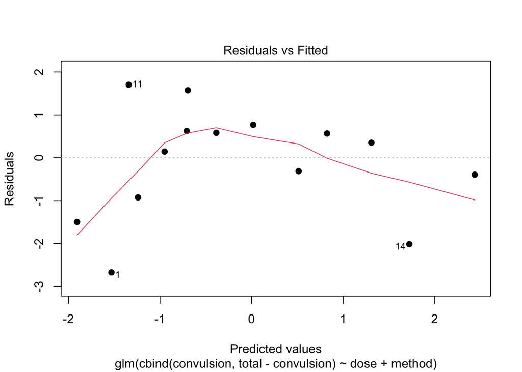

```r
plot(mice.fit, pch=19, which = 1)
```

It is difficult to interpret the residual plots as we have a small number of data. The Pearson and residuals appear to have more variation that we might expect under the model. If the model is appropriate, we expect the Pearson and deviance residuals to have an approximate Normal(0,1) distribution. This means that most of the residuals would lie between -2 and +2. This does not appear to be the case as two out of fourteen residuals seem to be outside of this range. Furthermore, it is possible that we may be dealing with sparse data. We can see that the expected value of the response is less than 5 for several mice. This indicates that there may be problems with the model.

The cooks distance plot shows that there are 3 points of undue influence as these observations have a cook’s distance of over 0.4. Observation 14 in particular has an extremely high cook’s distance which suggests that there may be problems with the model.

The residuals vs Fitted values plot show evidence of non-linearity.

### c)

```r
1 - pchisq(deviance(mice.fit), df.residual(mice.fit))
```

```
## [1] 0.00444048
```

The test indicates that we have strong evidence against the null hypothesis that our model is correct. It is questionable whether or not the assumption that $n_i$ > 5 is reasonable and therefore the deviance may not come from a chi-squared distribution with 11 degrees of freedom.

### d)

```r
cfs <- coef(mice.fit)
set.seed(123456)
Dose = mice.df$dose
Method = mice.df$method
xbeta = cfs[1] + cfs[2] * Dose + cfs[3]
n = mice.df$total
n.obs = nrow(mice.df)
Nsim = 1e4
devs <- numeric(Nsim)
for (i in 1:Nsim) {
  ysim = rbinom(n.obs, size = n, prob = exp(xbeta)/(1+exp(xbeta)))
  mod_i = glm(cbind(ysim, n-ysim)~Dose+ Method, family = "binomial")
  devs[i] = deviance(mod_i)
}
```

### (i)

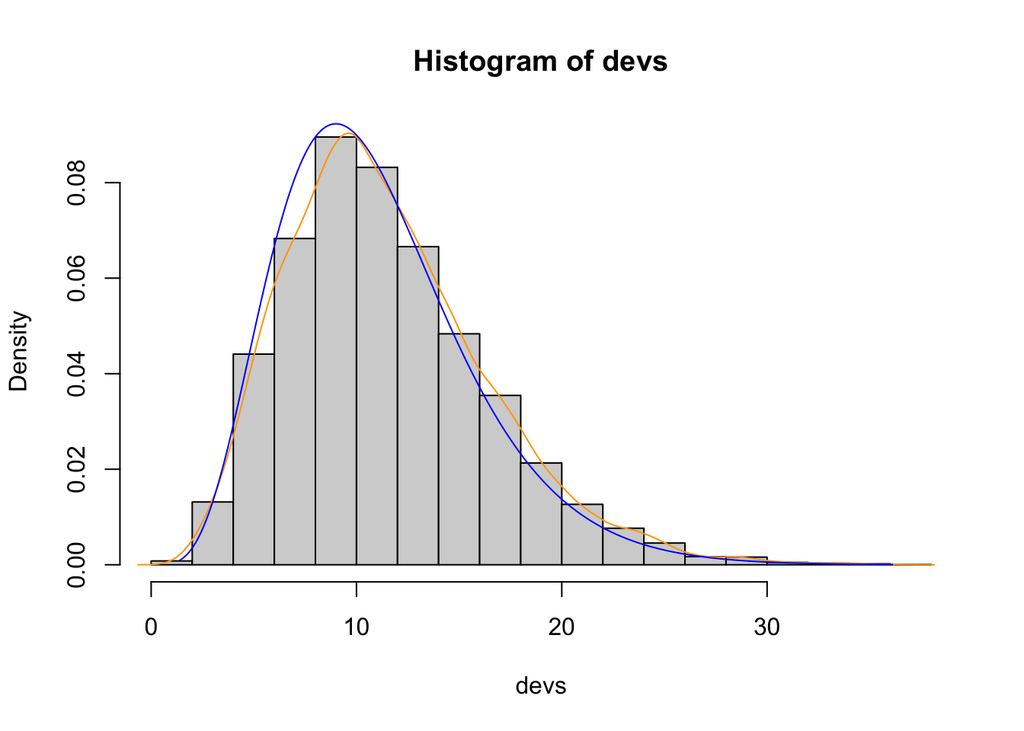

```r
hist(devs, freq = FALSE)
lines(density(devs), col = "orange")
ds <- seq(min(devs), max(devs), length = 1e3)
lines(ds, dchisq(ds, df = df.residual(mice.fit)), col = "blue")
```

The plot shows that there is a difference between the bootstrap generated reference distribution and the chi-square reference distribution. The bootstrapped distribution is more towards the right. This suggests that there may be a problem and it may not be reasonable the deviance comes from a chi-squared distribution with 11 degrees of freedom.

### (ii)

```r
sum(devs > 27.098)/Nsim
```

```
## [1] 0.0067
```

The p-value for the goodness of fit test using the bootstrap generated reference distribution is slightly higher than the p-value obtained using the chi-square distribution. However, the p-value is still very small and provides evidence to reject the null hypothesis that the model is correct. Additionally it provides further evidence to our previous conclusions about the goodness of fit test. It shows that the deviance aren’t well approximated by a $X^2_{df = 11}$ distribution and suggests that the assumption has not been met.

### (iii)

Nonparametric bootstrap should not be used to generate a reference distribution for a goodness of fit test because nonparametric bootstrap will resample after the original observations with replacement. This will not take into account the binomial model that we fitted as the nonparametric does not assume that the estimated model is the true model. The data should also be independent for nonparametric bootstrap and it does not seem like all of our data is independent. We also only have a small number of observations and the nonparametric bootstrap sample on average omits 37% of the data. We cannot be sure that it would produce a sampling distribution that is valid under the null hypothesis.

### e)

```r
mice.fit2 <-  glm(cbind(convulsion, total - convulsion) ~ log(dose) + method, family = "binomial")
summary(mice.fit2)
```

```
##
## Call:
## glm(formula = cbind(convulsion, total - convulsion) ~ log(dose) +
##     method, family = "binomial")
##
## Deviance Residuals:
##      Min        1Q    Median        3Q       Max
## -2.03026  -0.39653  -0.01947   0.34974   1.24987
##
## Coefficients:
##                       Estimate Std. Error z value Pr(>|z|)
## (Intercept)            -6.4822     0.6276  -10.33  < 2e-16 ***
## log(dose)               2.2972     0.2196   10.46  < 2e-16 ***
## methodStandard Method   0.9290     0.2334    3.98 6.89e-05 ***
## ---
## Signif. codes:  0 '***' 0.001 '**' 0.01 '*' 0.05 '.' 0.1 ' ' 1
##
## (Dispersion parameter for binomial family taken to be 1)
##
##     Null deviance: 166.8335  on 13  degrees of freedom
## Residual deviance:   8.7912  on 11  degrees of freedom
## AIC: 62.644
##
## Number of Fisher Scoring iterations: 4
```

```r
1-pchisq(8.79,11)
```

```
## [1] 0.6412692
```

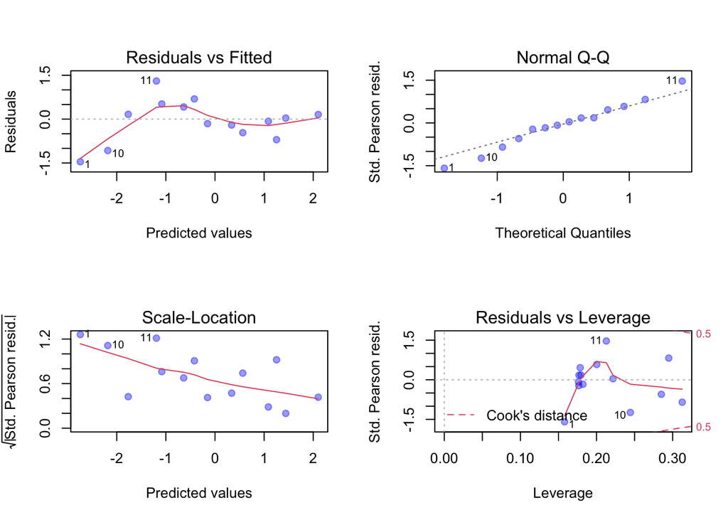

```r
par(mfrow=c(2,2))
plot(mice.fit2,pch=19,col=rgb(0,0,1,.4))
```

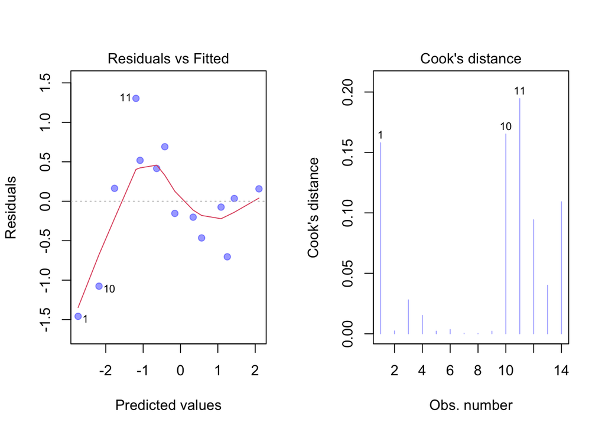

```r
 par(mfrow=c(1,2))
plot(mice.fit2,pch=19,col=rgb(0,0,1,.4), which=c(1,4))
```

The log dose model seems a much better fit to the data. The residual deviance is much smaller (8.8 compared to 27.1), there is now no evidence of lack-of-fit (p-value is .64) and the value of AIC is much smaller (62.6 compared to 81). Also the diagnostic plots look better: improved with respect to linearity and there are no points with high values of Cook’s distance.

### f)

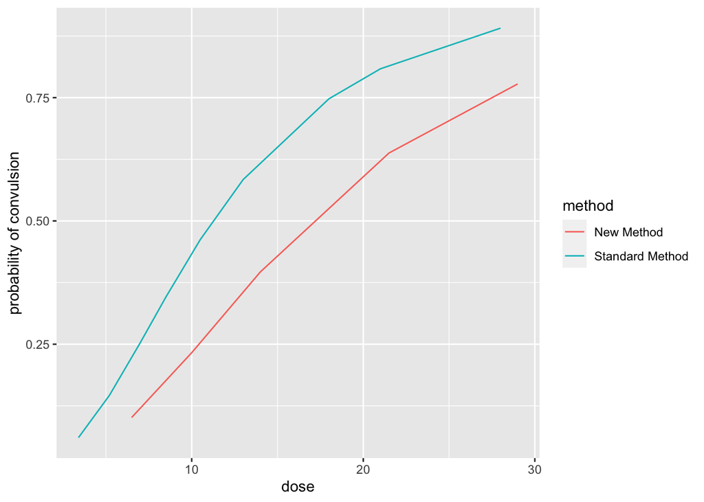

```r
mice.df %>%
  mutate(p = predict(mice.fit2, type = "response")) %>%
  ggplot(aes(x = dose, y = p)) +
  geom_line(aes(color = method)) +
  labs(y = "probability of convulsion")
```

```r
exp(coef(mice.fit2))
```

```
##           (Intercept)             log(dose) methodStandard Method
##           0.001530505           9.945831376           2.532031402
```

A plot of the estimated probability of convulsions for each method over the range of values for dose. This plot shows that for most of the range of dose, the probability of convulsions is between .1 and .2 smaller for the new method compared to the standard method.

## Question 2 Fitness

One indicator of the aerobic fitness of a person is their oxygen consumption measured as milliliters of oxygen consumed per kilogram of body weight per minute. Measurements of oxygen consumption and of six possible explanatory variables were taken for 31 individuals. The goal was to determine whether it was possible to predict oxygen consumption using the other variables.

### a)

```r
fitness.df <- read_table("fitness.data")
fitness.df <- fitness.df %>%
  separate(`run  rest.p`, into = c("run", "rest.p"), sep = "  ") %>%
  mutate(run = as.numeric(run),
         rest.p = as.integer(rest.p),
         age = as.integer(age),
         run.p = as.integer(run.p),
         max.p = as.integer(max.p))

fitness.df <- data.frame(fitness.df)
str(fitness.df)
```

```
## 'data.frame':    31 obs. of  7 variables:
##  $ oxy   : num  44.6 45.3 54.3 59.6 49.9 ...
##  $ age   : int  44 40 44 42 38 47 40 43 44 38 ...
##  $ wt    : num  89.5 75.1 85.8 68.2 89 77.5 76 81.2 81.4 81.9 ...
##  $ run   : num  11.37 10.07 8.65 8.17 9.22 ...
##  $ rest.p: int  62 62 45 40 55 58 70 64 63 48 ...
##  $ run.p : int  178 185 156 166 178 176 176 162 174 170 ...
##  $ max.p : int  182 185 168 172 180 176 180 170 176 186 ...
```

```r
summary(fitness.df)
```

```
##       oxy             age              wt             run
##  Min.   :37.39   Min.   :38.00   Min.   :59.10   Min.   : 8.17
##  1st Qu.:44.96   1st Qu.:44.00   1st Qu.:73.20   1st Qu.: 9.78
##  Median :46.77   Median :48.00   Median :77.50   Median :10.47
##  Mean   :47.38   Mean   :47.68   Mean   :77.45   Mean   :10.59
##  3rd Qu.:50.13   3rd Qu.:51.00   3rd Qu.:82.35   3rd Qu.:11.27
##  Max.   :60.06   Max.   :57.00   Max.   :91.60   Max.   :14.03
##      rest.p          run.p           max.p
##  Min.   :40.00   Min.   :146.0   Min.   :155.0
##  1st Qu.:48.00   1st Qu.:163.0   1st Qu.:168.0
##  Median :52.00   Median :170.0   Median :172.0
##  Mean   :53.45   Mean   :169.6   Mean   :173.8
##  3rd Qu.:58.50   3rd Qu.:176.0   3rd Qu.:180.0
##  Max.   :70.00   Max.   :186.0   Max.   :192.0
```

### b)

```r
diag(solve(cor(fitness.df[,-1])))
```

```
##      age       wt      run   rest.p    run.p    max.p
## 1.513279 1.155913 1.591233 1.415495 8.437226 8.743507
```

All of the variance inflation factors are below 5 except those for run.p and max.p which are both approximately 8. Thus the only circumstance where multicolinearity may be an issue is if both run.p and max.p are included in the model.

### c)

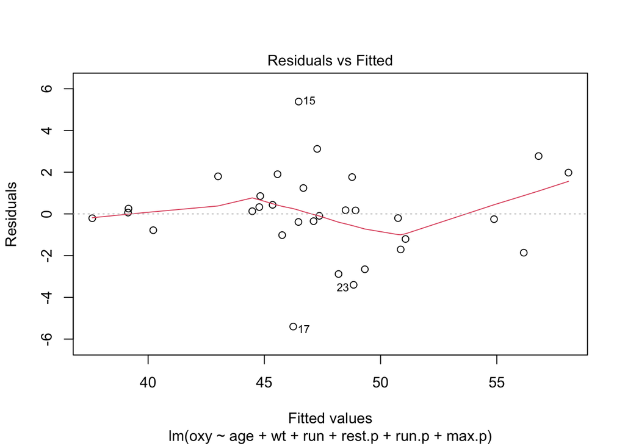

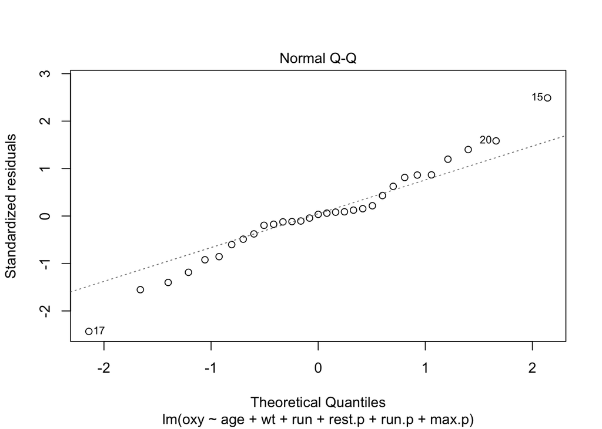

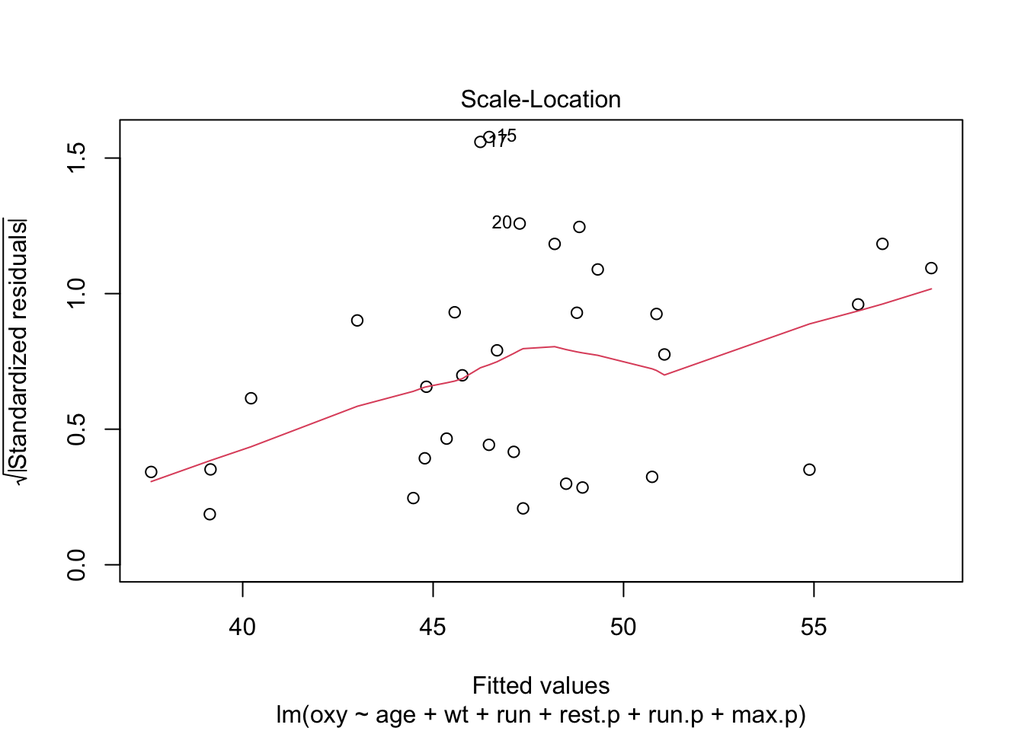

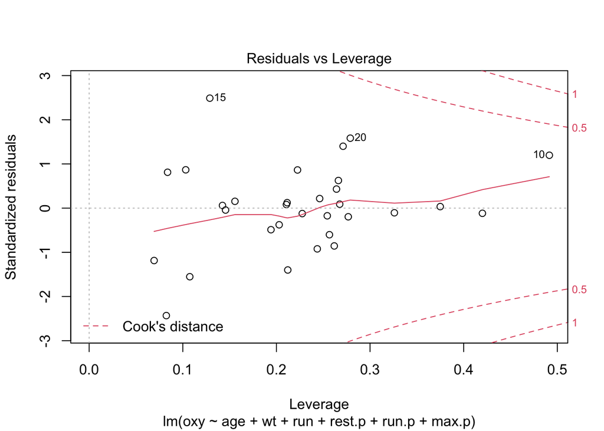

```r
fitness.fit <- lm(oxy ~ age + wt + run + rest.p + run.p + max.p, data = fitness.df)
plot(fitness.fit)
```

```r
summary(fitness.fit)
```

```
##
## Call:
## lm(formula = oxy ~ age + wt + run + rest.p + run.p + max.p, data = fitness.df)
##
## Residuals:
##     Min      1Q  Median      3Q     Max
## -5.4012 -0.8982  0.0637  1.0496  5.3854
##
## Coefficients:
##              Estimate Std. Error t value Pr(>|t|)
## (Intercept) 102.90509   12.41184   8.291 1.67e-08 ***
## age          -0.22670    0.09990  -2.269  0.03253 *
## wt           -0.07400    0.05468  -1.353  0.18858
## run          -2.62929    0.38481  -6.833 4.57e-07 ***
## rest.p       -0.02137    0.06609  -0.323  0.74925
## run.p        -0.37006    0.11992  -3.086  0.00505 **
## max.p         0.30365    0.13656   2.223  0.03585 *
## ---
## Signif. codes:  0 '***' 0.001 '**' 0.01 '*' 0.05 '.' 0.1 ' ' 1
##
## Residual standard error: 2.318 on 24 degrees of freedom
## Multiple R-squared:  0.8486, Adjusted R-squared:  0.8107
## F-statistic: 22.41 on 6 and 24 DF,  p-value: 9.794e-09
```

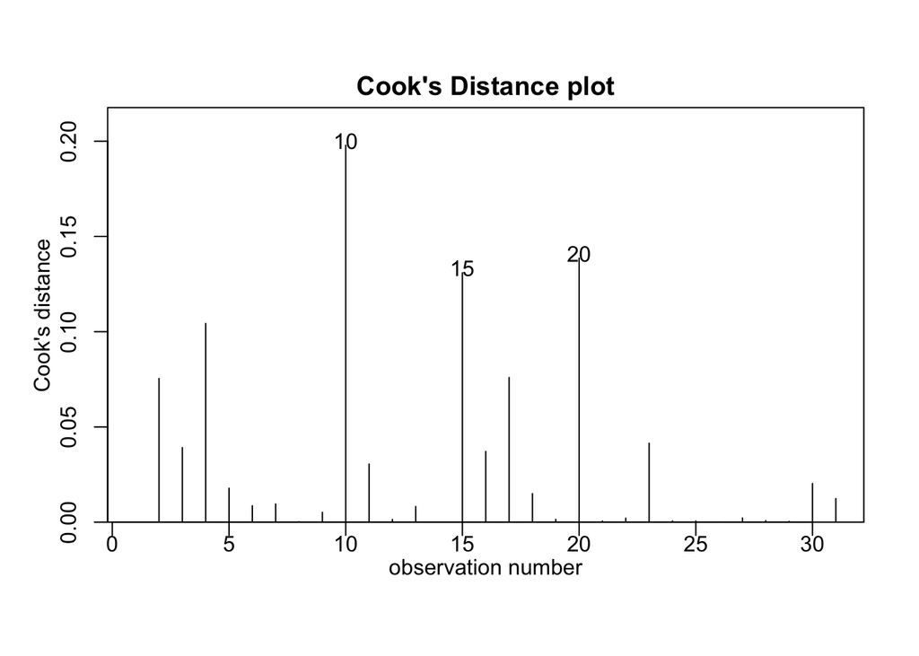

```r
cooks20x(fitness.fit)
```

The residuals vs fitted values plot shows a slight pattern but otherwise appears fairly normal. This shows that there is no indication of non-linearity. The Q-Q plot shows that there may be a few outliers. The positive trend in the scale location plot indicates there may be non-constant variance. The cook’s distance plot suggests there are no influential points.

### d)

```r
library(MuMIn)
options(na.action = "na.fail")
all.fits <- dredge(fitness.fit)
```

```
## Fixed term is "(Intercept)"
```

```r
all.fits2 <- dredge(fitness.fit, rank = "BIC")
```

```
## Fixed term is "(Intercept)"
```

```r
head(all.fits)
```

```
## Global model call: lm(formula = oxy ~ age + wt + run + rest.p + run.p + max.p, data = fitness.df)
## ---
## Model selection table
##     (Int)     age  max.p    rst.p    run   run.p       wt df  logLik  AICc
## 28  98.13 -0.1975 0.2711          -2.768 -0.3486           6 -67.244 150.0
## 60 102.20 -0.2194 0.3053          -2.683 -0.3738 -0.07214  7 -66.152 151.2
## 26 111.70 -0.2563                 -2.826 -0.1310           5 -69.521 151.4
## 27  80.90         0.3547          -2.970 -0.3756           5 -69.597 151.6
## 32  98.47 -0.2012 0.2696 -0.01197 -2.739 -0.3461           7 -67.224 153.3
## 58 115.70 -0.2762                 -2.773 -0.1294 -0.04912  6 -69.076 153.7
##    delta weight
## 28  0.00  0.353
## 60  1.18  0.195
## 26  1.45  0.171
## 27  1.61  0.158
## 32  3.33  0.067
## 58  3.67  0.056
## Models ranked by AICc(x)
```

```r
head(all.fits2)
```

```
## Global model call: lm(formula = oxy ~ age + wt + run + rest.p + run.p + max.p, data = fitness.df)
## ---
## Model selection table
##     (Int)     age  max.p    rst.p    run   run.p       wt df  logLik   BIC
## 28  98.13 -0.1975 0.2711          -2.768 -0.3486           6 -67.244 155.1
## 26 111.70 -0.2563                 -2.826 -0.1310           5 -69.521 156.2
## 60 102.20 -0.2194 0.3053          -2.683 -0.3738 -0.07214  7 -66.152 156.3
## 27  80.90         0.3547          -2.970 -0.3756           5 -69.597 156.4
## 32  98.47 -0.2012 0.2696 -0.01197 -2.739 -0.3461           7 -67.224 158.5
## 58 115.70 -0.2762                 -2.773 -0.1294 -0.04912  6 -69.076 158.8
##    delta weight
## 28  0.00  0.336
## 26  1.12  0.192
## 60  1.25  0.180
## 27  1.27  0.178
## 32  3.39  0.061
## 58  3.67  0.054
## Models ranked by BIC(x)
```

I used dredge() for AICc and BIC as the selection criteria. Both had the same top 6 models although the order was slightly different. Therefore, I will use the 6 models above as the promising models.

### e)

```r
library(crossval)
predfun.lm <- function(train.x, train.y, test.x, test.y) {
lm1.fit <- lm(train.y ~ age + max.p + run + run.p, data = train.x)
  ynew <- predict(lm1.fit, test.x)
  out1 <- mean((ynew - test.y)^2)


lm2.fit <- lm(train.y ~ age + max.p + run + run.p + wt, data = train.x)
  ynew <- predict(lm2.fit, test.x)
  out2 <- mean((ynew - test.y)^2)

lm3.fit <- lm(train.y ~ age + run + run.p, data = train.x)
  ynew <- predict(lm3.fit, test.x)
  out3 <- mean((ynew - test.y)^2)

lm4.fit <- lm(train.y ~ max.p + run + run.p, data = train.x)
  ynew <- predict(lm4.fit, test.x)
  out4 <- mean((ynew - test.y)^2)

lm5.fit <- lm(train.y~ age + max.p + rest.p + run + run.p, data = train.x)
  ynew <- predict(lm5.fit, test.x)
  out5 <- mean((ynew - test.y)^2)

lm6.fit <- lm(train.y ~ age + run + run.p + wt, data = train.x)
  ynew <- predict(lm6.fit, test.x)
  out6 <- mean((ynew - test.y)^2)

c(out1, out2, out3, out4, out5, out6)
}

cv.out = crossval(predfun.lm, X = fitness.df[, 2:7],Y = fitness.df[, 1], K = 10, B = 100, verbose = FALSE)
round(cv.out$stat, 2)
```

```
## [1] 6.09 5.90 6.64 6.84 6.55 6.91
```

The model with the lowest estimated MSPE is model 60 which has age, max.p, run, run.p and weight as explanatory variables.